# **`1. Introduction to R`**

### **`1.1 Getting Started with R`**

#### **`1.1.1 Install R and RStudio`**

- What is R? [The R Project for Statistical Computing](https://www.r-project.org/).
- Download and install R from [The Comprehensive R Archive Network (CRAN)](https://cran.r-project.org/mirrors.html).
- Download and install RStudio (optional) from [www.rstudio.com](https://www.rstudio.com/).

#### **`1.1.2 Getting started with the RStudio interface`**

- [Writing R Code in RStudio](https://www.rstudio.com/resources/webinars/rstudio-essentials-webinar-series-part-1/).

#### **`1.1.3 R Packages`**

R functions, documentations and (built-in) data are stored in various packages. These contents are available to users only when the according package is loaded. R comes with a `base` package and a set of “recommended” packages that contain many fundamental functions of R. There are numerous contributed (user-written) R packages that substantially extend the functionality of the “base” R system. Most of contributed packages are available for downloading from CRAN.

- install package `x` from CRAN: `install.packages("x")`.
- get help (documentation) on package `x`: `help(package = "x")`.
- load package `x` to R: `library(x)`.
- update package `x` from CRAN: `update.packages("x")`.
- remove package `x` from R: `remove.packages("x")`.
- get a list of installed packages: `library()`.
- get a list of currently loaded packages: `search()`.

There are many contributed packages very useful for econometric and statistical analysis: `simstudy`, `Hmisc`, `ggplot2`, `ggpubr`, `readr`, `dplyr`, `DBI`, `numDeriv`, `rootSolve`, `TSA`, `ISLR`, `latex2exp`, among many others.

### **`1.2 Preliminaries of R`**

How to get help in R?

- Access help files using the `help()` function or simply `?` operator, e.g., `?mean`.
- Type a function name to see its syntax, e.g., `mean`.
- Start the HTML help system using the `help.start()` function.
- Search help files using the `help.search()` function.

Some must-know facts about R:

- R is case sensitive.
- All alphanumeric symbols plus `.` and `_` can be used to name variables in R.
- R comments start with a hash mark `#`. R does not support multi-line comments or comment blocks.
- R commands are separated either by `;` or a new line.
- An R script (.R file) is a collection of R commands.
- To execute commands stored in external R scripts, use `source("filename.R")`.
- One can split a long command into multiple lines by ending a line with an operator, then R will automatically search the next line.
- One can group elementary commands using braces `{` and `}`.
- In RStudio, one can use the `Tab` key when coding to get a list of suggestions from R.
- To interrupt the execution of a running R code, use `ESC` in RStudio or `Command + C` in R shell.
- One can use `sink("/dev/null")` to suppress the output of running R commands and use `sink()` to turn the output display back on.

### **`1.3 Numbers and Vectors`**

Numbers in R are double precision real numbers by default. To specify an integer, one can use the `L` operator.

```r
a.num <- 1; a.int <- 1L
class(a.num); class(a.int)
```

```
## [1] "numeric"
```

```
## [1] "integer"
```

Regular sequences of numbers can be generated using the `:` operator or more flexibly using the `seq()` function. Note that the `:` operator has high priority in all expressions!

```r
1:10; 10:1
```

```
##  [1]  1  2  3  4  5  6  7  8  9 10
```

```
##  [1] 10  9  8  7  6  5  4  3  2  1
```

```r
2*1:5; (2*1):5
```

```
## [1]  2  4  6  8 10
```

```
## [1] 2 3 4 5
```

```r
seq(2, 8, by = 0.5)
```

```
##  [1] 2.0 2.5 3.0 3.5 4.0 4.5 5.0 5.5 6.0 6.5 7.0 7.5 8.0
```

```r
seq(length = 5, by = 1, from = 2)
```

```
## [1] 2 3 4 5 6
```

A vector is a set of values with the same class. The `c()` function can be used to create vectors.

```r
x <- c(10.4, 5.6, 3.1, 6.4, 21.7)
y <- c(x, 0, x)
x; y
```

```
## [1] 10.4  5.6  3.1  6.4 21.7
```

```
##  [1] 10.4  5.6  3.1  6.4 21.7  0.0 10.4  5.6  3.1  6.4 21.7
```

One can use the `vector()` function to create vectors of all zeros or initialize vectors of all entries the same.

```r
vector("numeric", length = 5) + 1
```

```
## [1] 1 1 1 1 1
```

The `vector()` function can also be used to create “empty” vectors, which are sometimes useful in loopings.

```r
vector("numeric"); vector("integer"); vector("character")
```

```
## numeric(0)
```

```
## integer(0)
```

```
## character(0)
```

Arithmetic operators (e.g., `+`, `-`, `*`, `/`, `^`, `log()`, `exp()`, `sin/cos/tan()`, `round/ceiling/floor/trunc()`, etc) in R performs element-by-element operations.

```r
round(sqrt(y) + y/c(x, 1, x), 3)
```

```
##  [1] 4.225 3.366 2.761 3.530 5.658 0.000 4.225 3.366 2.761 3.530 5.658
```

R’s logical operators include `<`, `<=`, `>`, `>=`, `==`, `!=`, `&`, `|`, which returns a logical vector with either `TRUE` or `FALSE` as elements. Note that logical vectors can be used in ordinary arithmetic, `FALSE = 0`, `TRUE = 1`.

```r
a <- x < 7
2*a + 1
```

```
## [1] 1 3 3 3 1
```

In R, arithmetic operations on vectors follow the “recycling rule”, i.e., shorter vectors in an expression will be recycled as often as need be when the length of the longest vector is a multiple of that of shorter vectors.

```r
u <- c(x, x)
2*x + u + 1
```

```
##  [1] 32.2 17.8 10.3 20.2 66.1 32.2 17.8 10.3 20.2 66.1
```

R comes with numerous vector functions like `max/min/quantile()`, `range/length()`[^1], `mean/median/var()`[^2], `sort/order()`, `pmax/pmin()` (parallel max/min for more than 1 vectors), etc. Note that for the arguments of any R function can be called either by its name or by its order (position), while the former is highly recommended as the order of function arguments in this case is irrelevant. Moreover, partial matching (i.e., use the abbreviation of an argument name) of function arguments is also allowed in R.

Vectors may contain “special” elements such as `inf` (infinity), `NA` (missing values)[^3] and `NaN` (not a number).

```r
1/0; exp(10^10); 0/0
```

```
## [1] Inf
```

```
## [1] Inf
```

```
## [1] NaN
```

```r
b <- c(1:3, NA); b; b == NA
```

```
## [1]  1  2  3 NA
```

```
## [1] NA NA NA NA
```

To identify these special elements, one can use `is.infinite/is.na/is.nan()` functions[^4]. Note that `is.na()` is TRUE for both NAs and NaNs, but `is.nan()` is TRUE only for NaNs.

```r
d <- c(b, 0/0)
is.na(b); is.nan(d); is.na(d)
```

```
## [1] FALSE FALSE FALSE  TRUE
```

```
## [1] FALSE FALSE FALSE FALSE  TRUE
```

```
## [1] FALSE FALSE FALSE  TRUE  TRUE
```

R vectors can be subset and modified using the `[]` operator. Note that the `[]` operator always returns an object of the same class as the original.

```r
d[!is.na(d)]
```

```
## [1] 1 2 3
```

```r
(d*2)[(!is.na(d))&(d>1)]
```

```
## [1] 4 6
```

```r
v <- 1:15
v[1:10]
```

```
##  [1]  1  2  3  4  5  6  7  8  9 10
```

```r
v[-(1:5)]
```

```
##  [1]  6  7  8  9 10 11 12 13 14 15
```

```r
v[2*1:5]; v[(2*1):5]
```

```
## [1]  2  4  6  8 10
```

```
## [1] 2 3 4 5
```

```r
b[is.na(b)] <- 0
x[x>10] <- -x[x>10]
```

Once the elements of a vector is labeled, they can be selected by their labels.

```r
w <- 1:3
# add names (or say labels) to vector elements
names(w) <- c("w1", "w2", "w3")
# subset a vector using labels
w[c("w1", "w3")]
```

```
## w1 w3
##  1  3
```

One can replicate vector elements using the `rep()` function.

```r
# replicate z for 5 times
rep(b, times = 5)
```

```
##  [1] 1 2 3 0 1 2 3 0 1 2 3 0 1 2 3 0 1 2 3 0
```

```r
# repeat each element 5 times before moving to the next
rep(b, each = 5)
```

```
##  [1] 1 1 1 1 1 2 2 2 2 2 3 3 3 3 3 0 0 0 0 0
```

```r
# more complex case
c("x", "y")[rep(c(1, 2, 2, 1), times = 3)]
```

```
##  [1] "x" "y" "y" "x" "x" "y" "y" "x" "x" "y" "y" "x"
```

One can truncate/extend a vector by modifying its length.

```r
v <- vector("numeric")
# make v a vector of length 5 with the first 4 elements NA
v[5] <- 7; v
```

```
## [1] NA NA NA NA  7
```

```r
# retain just the first 3 elements
length(v) <- 3; v
```

```
## [1] NA NA NA
```

```r
# extend a vector (with NA)
length(v) <- 10; v
```

```
##  [1] NA NA NA NA NA NA NA NA NA NA
```

For multiple vectors (or more often data), one can use the `complete.cases()` function to return a logical vector indicating which cases have no missing values.

```r
h <- c(1, 2, NA, 4, NA, 5)
g <- c(3, 4, NA, NA, 7, 8)
# keep a subset of multiple objects without NA
h[complete.cases(h, g)]
```

```
## [1] 1 2 5
```

```r
g[complete.cases(h, g)]
```

```
## [1] 3 4 8
```

### **`1.4 R Objects: Attributes, Mode, Class and Structure`**

The entities that R operates on are called objects. R stores all of its objects in physical memory. One can use `ls()` to display the names of objects currently stored in R and use the `rm()` function to remove objects, e.g., `rm(x, y)` (remove selected objects x and y), `rm(list = ls())` (clear all objects in current environment), etc.

All R objects have

- Attributes: metadata for an object which help to describe the object[^5].
- Mode: a mutually exclusive classification of objects according to their basic structures.
- Class: a property assigned to an object that determines how generic functions operate with it.

Attributes of an R object can be accessed using the `attributes()` function.

```r
strings <- "hello world!"
A <- matrix(rnorm(3^2), 3, 3)
library(readr)
setwd("/Users/ouyangfu/Dropbox/Notes/Software and Coding/R/data")
data <- read_csv("olsData.csv", n_max = 5)
f <- function(x,y){x^2+sin(y)}
attributes(strings); attributes(A); attributes(data); attributes(f)
```

```
## $dim
## [1] 3 3
```

```
## $names
## [1] "X1" "X2" "X3" "X4" "Y"
##
## $class
## [1] "tbl_df"     "tbl"        "data.frame"
##
## $row.names
## [1] 1 2 3 4 5
##
## $spec
```

```
## $srcref
## function(x,y){x^2+sin(y)}
```

Each R object has one and only one mode. One can check the mode of an R object with the `mode()` function. R modes include character, numeric (real numbers), logical (T/F), list, function, etc.

```r
mode(strings); mode(A); mode(data); mode(f)
```

```
## [1] "character"
```

```
## [1] "numeric"
```

```
## [1] "list"
```

```
## [1] "function"
```

```r
TF <- F; mode(TF)
```

```
## [1] "logical"
```

There is a large collection of `as.*()` functions for changing modes, which is often called “coercion”.

```r
# coercion may involve changes of object attributes
mode(as.data.frame(A)); attributes(as.data.frame(A))
```

```
## [1] "list"
```

```
## $names
## [1] "V1" "V2" "V3"
##
## $row.names
## [1] 1 2 3
##
## $class
## [1] "data.frame"
```

```r
mode(as.character(as.vector(A))); attributes(as.character(as.vector(A)))
```

```
## [1] "character"
```

Not like `mode`, `class` is not a mutually exclusive classification. If an R object has no specific class assigned to it (by a class attribute), it has an implicit class like “matrix”, “array” or the result of `mode()`. One can check the class of an R object with the `class()` function. The mode of an object can change without necessarily changing the class.

```r
# mode vs class
class(strings); class(A); class(data); class(f)
```

```
## [1] "character"
```

```
## [1] "matrix"
```

```
## [1] "tbl_df"     "tbl"        "data.frame"
```

```
## [1] "function"
```

```r
x <- 1:5
mode(as.matrix(x))
```

```
## [1] "numeric"
```

```r
class(as.matrix(x))
```

```
## [1] "matrix"
```

```r
mode(as.matrix(is.numeric(x)))
```

```
## [1] "logical"
```

```r
class(as.matrix(is.numeric(x)))
```

```
## [1] "matrix"
```

In practice, it is often more useful to understand the internal structure (including information on mode, class, attributes, among others like “length”“) of an R object before operating on it. The `str()` function can compactly display the internal structure of an R object.

```r
str(strings); str(A); str(f); str(data)
```

```
##  chr "hello world!"
```

```
##  num [1:3, 1:3] -0.436 1.605 1.154 0.195 1.369 ...
```

```
## function (x, y)
##  - attr(*, "srcref")=Class 'srcref'  atomic [1:8] 6 6 6 30 6 30 6 6
##   .. ..- attr(*, "srcfile")=Classes 'srcfilecopy', 'srcfile' <environment: 0x7f9a99133988>
```

```
## Classes 'tbl_df', 'tbl' and 'data.frame':    5 obs. of  5 variables:
##  $ X1: num  0.212 1.606 -1.573 1.143 2.821
##  $ X2: int  0 0 0 1 0
##  $ X3: num  1.667 -0.926 1.521 -0.84 0.898
##  $ X4: int  1 0 1 1 0
##  $ Y : num  -1.42 4.79 -2.29 4.25 4.01
##  - attr(*, "spec")=List of 2
##   ..$ cols   :List of 5
##   .. ..$ X1: list()
##   .. .. ..- attr(*, "class")= chr  "collector_double" "collector"
##   .. ..$ X2: list()
##   .. .. ..- attr(*, "class")= chr  "collector_integer" "collector"
##   .. ..$ X3: list()
##   .. .. ..- attr(*, "class")= chr  "collector_double" "collector"
##   .. ..$ X4: list()
##   .. .. ..- attr(*, "class")= chr  "collector_integer" "collector"
##   .. ..$ Y : list()
##   .. .. ..- attr(*, "class")= chr  "collector_double" "collector"
##   ..$ default: list()
##   .. ..- attr(*, "class")= chr  "collector_guess" "collector"
##   ..- attr(*, "class")= chr "col_spec"
```

### **`1.5 Factors`**

A factor is a vector object used to specify a discrete classification of the elements of another vector of the same length. Factors are often used as qualitative variables included in econometric and statistical models. Factor can be defined using the `factor()` function[^6]. The levels of factors are stored in alphabetical order by default. But this order can be set using the `levels` argument of `factor()`, which can be important in many choice models because the first level is often used as the base level (base/outside choice) by default[^7].

```r
# define a factor vector
# use the paste() fuction to concatenate numbers to character vectors
t <- paste("type", round(runif(100, 1, 3)), sep = "")
type <- factor(t)
# a table of frequencies of each level
table(type)
```

```
## type
## type1 type2 type3
##    31    48    21
```

```r
# find out the levels of the factor
levels(type)
```

```
## [1] "type1" "type2" "type3"
```

```r
# use "levels" option to specify the base level
levels(factor(t, levels = c("type3","type1","type2")))
```

```
## [1] "type3" "type1" "type2"
```

```r
# change the base level using the relevel() function
levels(relevel(type, ref = "type2"))
```

```
## [1] "type2" "type1" "type3"
```

```r
# use the cut() function to define (a,b]-type levels
p <- round(runif(100, 1, 9))
cp <- factor(cut(p, breaks = c(1, 3*(1:3))))
levels(cp)
```

```
## [1] "(1,3]" "(3,6]" "(6,9]"
```

```r
# a two-way table of frequencies
table(cp, type)
```

```
##        type
## cp      type1 type2 type3
##   (1,3]     6    16     4
##   (3,6]    14    19    10
##   (6,9]    10     7     7
```

### **`1.6 Lists`**

An R list is an object consisting of an ordered collection of objects known as its components, which can be thought of as a vector of values of possibly different classes. Lists can be created using the `list()` function. The components of list can be either named or numbered (if no names are assigned). The vector of component names is an attribute of the list and can be handled as such.

```r
Lst <- list(name = "Alex", num.children = 3, work = T, child.ages = c(4, 7, 9))
Lst
```

```
## $name
## [1] "Alex"
##
## $num.children
## [1] 3
##
## $work
## [1] TRUE
##
## $child.ages
## [1] 4 7 9
```

The `[[]]` operator can be used to extract single components from a list by either position or name indices (equivalent to using the `$` operator with component name).

```r
# extract components of a list by position
Lst[1]; Lst[[1]]
```

```
## $name
## [1] "Alex"
```

```
## [1] "Alex"
```

```r
# extract entries of a vector component of a list by position
Lst[[4]][1:2]
```

```
## [1] 4 7
```

```r
# number of components
length(Lst)
```

```
## [1] 4
```

```r
# names of list components
names(Lst)
```

```
## [1] "name"         "num.children" "work"         "child.ages"
```

```r
# structure of a list
str(Lst)
```

```
## List of 4
##  $ name        : chr "Alex"
##  $ num.children: num 3
##  $ work        : logi TRUE
##  $ child.ages  : num [1:3] 4 7 9
```

```r
# refer to components using names or name abbreviation (partial matching)
Lst$name; Lst[["name"]]
```

```
## [1] "Alex"
```

```
## [1] "Alex"
```

```r
Lst$child.ages[1:2]
```

```
## [1] 4 7
```

```r
Lst$chil[1:2]
```

```
## [1] 4 7
```

```r
# extend existing list (without component names)
Lst[5] <- list(c(1:5))
# concatenate lists (with component names kept)
c(Lst, list(country = "US"))
```

```
## $name
## [1] "Alex"
##
## $num.children
## [1] 3
##
## $work
## [1] TRUE
##
## $child.ages
## [1] 4 7 9
##
## [[5]]
## [1] 1 2 3 4 5
##
## $country
## [1] "US"
```

### **`1.7 Writing User's Own Functions`**

*Note: Some illustrating examples in this and next (1.8) sections involves some knowledge of R’s functions/operators associated with arrays (Section 2), probability and statistics (Section 3), and data frames (Section 4). If you do not have such knowledge, you may skip these examples for a while and revisit them after you reading the according sections.*

Writing functions is crucial for developing econometric and statistical methods. In R, functions are treated as an object. Note that in R

- Functions can be passed as arguments to other functions, e.g., the family of “apply” functions.
- Functions can be nested, i.e., a function can be defined inside another function.
- Functions can be used recursively, and may themselves define functions within themselves.
- A function can have another function as its return value.
- Functions always return the last expression evaluated in the function body.
- Any ordinary assignments done within the function are local and are invalid outside the function.

Functions in R can be defined using `function(arg1, arg2,...){expressions}`. The following example defines the log-likelihood function for a linear regression model
$$y_i=\beta_0+x_i'\beta_1+\epsilon_i, \epsilon_i\sim N(0,\sigma^2)$$
which has two arguments, $\theta=(\beta_0,\beta_1,\sigma^2)$ (parameters to estimate) and the data $\{x_i,y_i\}_{i=1}^{n}$.

```r
lrmLL <- function(theta, data) {
  eps <- .Machine$double.eps
  k <- ncol(data)-1
  x <- data[, 1:k]; y <- data[, k+1]
  beta <- theta[1:(k+1)]
  sig <- theta[k+1+1]
  mu <- cbind(1, x) %*% beta
  sum(log(dnorm(y, mu, sig + eps)))
}
```

One can define a function with optional arguments and/or specified default values for some arguments.

```r
f <- function(x, subset, c = 1) {
  i <- x[subset] > c
  x[subset][i]
}
set.seed(1)
x <- round(runif(10, 0, 2), 2)
# R function arguments can be matched by position or by name or their mix
x; f(x); f(c = 1.5, x); f(x, subset = c(1:5), 1.5)
```

```
##  [1] 0.53 0.74 1.15 1.82 0.40 1.80 1.89 1.32 1.26 0.12
```

```
## [1] 1.15 1.82 1.80 1.89 1.32 1.26
```

```
## [1] 1.82 1.80 1.89
```

```
## [1] 1.82
```

It is sometimes useful to allow an argument to take the `NULL` value, which may force one to take some specific action (e.g., provide a specific value for the (named) argument).

```r
f <- function(x, a = 1, b = 2, c = NULL) {
  a*x^2 + b*x + c
}
f(3); f(3, c = 1)
```

```
## numeric(0)
```

```
## [1] 16
```

```r
# displays argument names and corresponding default values
args(f)
```

```
## function (x, a = 1, b = 2, c = NULL)
## NULL
```

There is a special argument in R known as the `...` argument[^8], which indicates a variable number of arguments. Many generic functions have `...` argument allowing arbitrary number of passed arguments.

```r
args(mean)
```

```
## function (x, ...)
## NULL
```

Many functions have `...` argument because it is impossible to know the number of arguments in advance.

```r
args(paste)
```

```
## function (..., sep = " ", collapse = NULL)
## NULL
```

Using the `...` argument enables one to extend a function without copying the entire argument list of its original function.

```r
# log-likelihood function with sigma fixed to be 1
lrmLL.fix <- function(beta, ...) {
  theta <- c(beta, 1)
  lrmLL(theta, data)
}
```

It is often useful to create a “constructor function” (i.e., a function used to construct other functions) using “free variables” (FV) (in contrast to formal arguments).

```r
# define a function with FV
power <- function(x){x^n}
# get a list of all formal arguments
formals(power)
```

[output not shown]

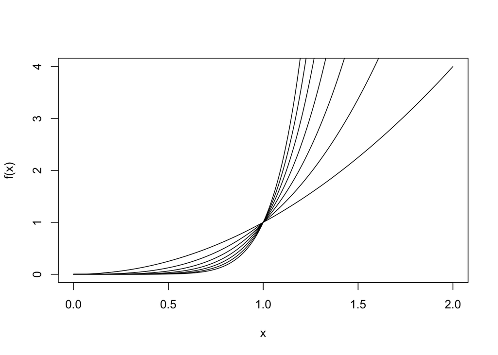

```r
# define a constructor function
powerf <- function(n) {
  power <- function(x){x^n}
  # powerf() returns a function object!
  power
}
x = seq(0, 2, by = 0.01)
plot(x, powerf(2)(x), type = "l", ylab = "f(x)")
for (n in 3:8) {
  lines(x, powerf(n)(x), type = "l")
}
```

The scoping rules of a language determine how a value is associated with a FV in a function. R (and Python) uses lexical (static) scoping, i.e., values of FV are found in the environment where the function was defined. An alternative to lexical scoping adopted by some other languages is called dynamic scoping, i.e., values of FV are found in the environment where the function was called. Lexical scoping turns out to be very suitable for statistical computations.

```r
# lexical vs dynamic scoping
y <- 3
g <- function(x) {x*y}
f1 <- function(x) {
  y <- 1; 2*y + g(x)
}
f2 <- function(x) {
  g <- function(x) {x*y}
  y <- 1; 2*y + g(x)
}
# free variable y = 3
f1(3)
```

```
## [1] 11
```

```r
# free variable y = 1
f2(3)
```

```
## [1] 5
```

Here is a more realistic example.

```r
# constructor function for generating negative log-likelihood functions
make.negloglike <- function(data, fixed = c(F, F)) {
  theta <- fixed
  function(p) {
    # data and theta are free variables
    theta[!fixed] <- p
    mu <- theta[1]; sig <- theta[2]
    a <- length(data)*log(2*pi*sig^2)
    b <- sum((data-mu)^2)/(sig^2)
    a + b
  }
}
set.seed(1)
data <- rnorm(250, 1, 2)
# ML criterion function for (mu, sigma)
negloglike <- make.negloglike(data)
# MLE for (mu, sigma)
optim(c(mu = 0, sig = 1), negloglike)
```

```
## $par
##       mu      sig
## 1.044408 1.921487
##
## $value
## [1] 1035.951
##
## $counts
## function gradient
##       61       NA
##
## $convergence
## [1] 0
##
## $message
## NULL
```

```r
# ML criterion function for mu only
negloglike.mu <- make.negloglike(data, fixed = c(F, 2))
optim(c(mu = 0), negloglike.mu)
```

```
## $par
##       mu
## 1.044531
##
## $value
## [1] 1036.737
##
## $counts
## function gradient
##       28       NA
##
## $convergence
## [1] 0
##
## $message
## NULL
```

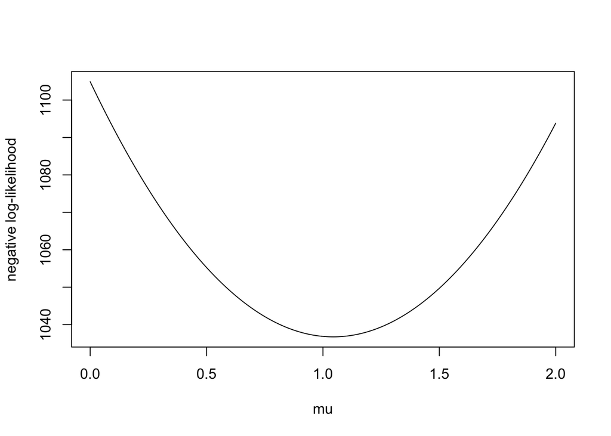

```r
mu <- seq(0, 2, length = 200)
nll <- sapply(mu, negloglike.mu)
plot(mu, nll, type = "l", ylab = "negative log-likelihood")
```

### **`1.8 Conditional Execution and Loops`**

#### **`1.8.1 if...else if...else`**

The `if...else if...else` structure allows one to first test a condition and then execute R expressions depending on the test result (i.e., True or False). The `stop()` function is often used in conjunction with a `if-else` combination to end an expression and return a self-defined error message. Note that `&&` and `||` compare just the *first* elements of each vector and return a single logical value, while `&` and `|` do element-wise comparisons between vectors and return a logical vector.

```r
f <- function(r) {
if (is.na(r) == 1 || is.nan(r) == 1 || length(r) > 1 || is.complex(r) == 1 ||
    r == Inf || is.character(r) == 1) {stop("not a real number")
} else if (r < 0) {print("negative real number")
} else if (r == 0) {print("zero")
} else {print("positive real number")}}

f(1); f(0); f(1/0)
```

```
## [1] "positive real number"
```

```
## [1] "zero"
```

```
## Error in f(1/0): not a real number
```

#### **`1.8.2 for loops`**

In R, `for` loops are most commonly used for iterating (successively) over the elements of an object (list, vector, etc.). Note that `for` loops can be nested inside of each other.

```r
A <- array(1:8, dim = c(2, 2, 2))
for (i in 1:nrow(A)) {
  for (j in seq_len(ncol(A))) {
    for (k in 1:dim(A)[3]) {
      print(A[i, j, k])
    }
  }
}
```

```
## [1] 1
## [1] 5
## [1] 3
## [1] 7
## [1] 2
## [1] 6
## [1] 4
## [1] 8
```

The iterator may not be an index-type variable.

```r
C = c("a", "b", "c", "d")
for (letter in C) {
  print(letter)
}
```

```
## [1] "a"
## [1] "b"
## [1] "c"
## [1] "d"
```

The `seq_along()` function is commonly used in conjunction with `for` loops in order to generate an integer sequence based on the length of an object.

```r
for (i in -seq_along(C)) {
  print(C[i])
}
```

```
## [1] "b" "c" "d"
## [1] "a" "c" "d"
## [1] "a" "b" "d"
## [1] "a" "b" "c"
```

#### **`1.8.3 while loops`**

A `while` loop starts from testing a condition. If it is true, then the loop body is executed. Once the execution is completed, the condition is tested again, and so forth, until the condition is false, after which the loop exits.

```r
r <- 2.5
while (r <= 5 && r >= 0) {
  dr <- rbinom(1, 1, .5)
  if (dr == 1) {
    r <- r + 1
  } else {
    r <- r -1
  }
  print(c(r, dr))
}
```

```
## [1] 3.5 1.0
## [1] 4.5 1.0
## [1] 5.5 1.0
```

#### **`1.8.4 repeat, break and next`**

The `repeat` initiates an infinite loop, which should generally be avoided whenever possible. The only way to exit a `repeat` loop is to call `break`. The `repeat` loop is typically employed when it is impossible to know in advance how many iterations it is going to take to fulfill the task.

```r
# example: search fixed point
x0 <- 0.01
g <- function(x) sqrt(x)
repeat {
  x1 <- g(x0)
  if (abs(x1 - x0) < 1e-4) {
    break
  } else {
    x0 <- g(x1)
    print(x0)
  }
}
```

```
## [1] 0.3162278
## [1] 0.7498942
## [1] 0.930572
## [1] 0.9821719
## [1] 0.9955129
## [1] 0.9988763
## [1] 0.999719
## [1] 0.9999297
```

One can use `next` to skip an iteration of a loop

```r
v <- vector(); v[10] <- NA
for (i in 1:10) {
  rv <- rnorm(1, 0, 1)
  if (rv < 0 || rv > 1) {
    next
  }
  v[i] <- round(rv, 1)
}
print(v)
```

```
##  [1] 0.4  NA  NA 0.1  NA 0.6  NA 0.1 0.4 0.6
```

#### **`1.8.5 Loop Functions`**

R comes with some loop functions which can implement looping in a compact form. Using these functions makes R code (often) faster and more reader-friendly than writing `for` loops. Frequently used loop functions include:

- `lapply()`: Loop over a list and evaluate a function on each element
- `sapply()`: Same as lapply but try to simplify the result
- `apply()`: Apply a function over the margins of an array
- `tapply()`: Apply a function over subsets of a vector
- `mapply()`: Multivariate version of lapply

The `lapply()` function loops over a list, evaluates a function on each element and returns a list. Using `lapply()` is fast as its looping is done internally in C code.

```r
lst <- list(x1 = 1, x2 = 2, x3 = 3)
lapply(lst, log)
```

```
## $x1
## [1] 0
##
## $x2
## [1] 0.6931472
##
## $x3
## [1] 1.098612
```

```r
# automatically coerce non-list object using as.list()
lapply(1:3, log)
```

```
## [[1]]
## [1] 0
##
## [[2]]
## [1] 0.6931472
##
## [[3]]
## [1] 1.098612
```

```r
# use lapply() with anonymous function
lapply(lst, function(x){round(log(x), 2)})
```

```
## $x1
## [1] 0
##
## $x2
## [1] 0.69
##
## $x3
## [1] 1.1
```

```r
# pass arguments down to the function being applied
lapply(lst, log, 2)
```

```
## $x1
## [1] 0
##
## $x2
## [1] 1
##
## $x3
## [1] 1.584963
```

```r
lst <- list(x1 = rnorm(200, 0, 1), x2 = rnorm(200, 0, 2))
lapply(lst, sd)
```

```
## $x1
## [1] 1.050931
##
## $x2
## [1] 1.936973
```

The `sapply()` function calls `lapply()` but returns a vector/matrix instead of a list, if possible.

```r
sapply(lst, sd)
```

```
##       x1       x2
## 1.050931 1.936973
```

The `split()` function creates a list of objects via splitting a larger object according to a factor

```r
x <- c(rnorm(500), runif(500), rnorm(500, 0, 2))
# generate levels in factor variable
f <- gl(3, 500)
# use lapply()/sapply() in conjection with split()
sapply(split(x, f), sd)
```

```
##         1         2         3
## 1.0242058 0.2911784 2.1266323
```

The combination of `sapply()` and `split()` is very useful in data analysis.

```r
library(readr)
setwd("/Users/ouyangfu/Dropbox/Notes/Software and Coding/R/data")
data <- read_csv("olsData.csv")
attach(data)
# split data frame by categorical variable
sapply(split(data, X2), function(x){colMeans(x[, c("X1", "X3")], na.rm = T)})
```

```
##              0          1
## X1 -0.20392479 -0.2010737
## X3 -0.04231798 -0.1104012
```

```r
# split data frame by interaction of categorical variables
# = split(data, list(X2, X4))
sapply(split(data, interaction(X2, X4), drop = T), function(x){colMeans(x[, c("X1", "X3")], na.rm = T)})
```

```
##            0.0         1.0        0.1        1.1
## X1 -0.19502945 -0.18662377 -0.2107957 -0.2138433
## X3  0.08620379 -0.05028599 -0.1415900 -0.1635263
```

The `tapply()` function is roughly equivalent to `split() + sapply()`, which is applied to vector only.

```r
# = sapply(split(x, f), sd)
tapply(x, f, sd)
```

```
##         1         2         3
## 1.0242058 0.2911784 2.1266323
```

The `apply()` function applies a function over subsets of an array (typically by rows/columns). To use `apply()`, it is important to correctly specify the `MARGIN` argument which is a vector indicating the subscripts which the function will be applied over. Note that using `apply()` is not really faster than writing a loop, but it is compact and more readable.

```r
X <- matrix(rnorm(12), nrow = 3, 4)
apply(X, 1, sum) == rowSums(X)
```

```
## [1] TRUE TRUE TRUE
```

```r
apply(X, 2, mean) == colMeans(X)
```

```
## [1] TRUE TRUE TRUE TRUE
```

```r
# more complicated example: preserve dim 1 & 3, collapse dim 2
A <- array(rnorm(4*10*2), c(4, 10, 2))
apply(A, c(1, 3), quantile, c(.25, .75))
```

```
## , , 1
##
##           [,1]       [,2]       [,3]       [,4]
## 25% -0.6264107 -0.8161993 -0.7019498 -0.3965802
## 75%  0.3322335  0.2235258 -0.1371298  0.8329053
##
## , , 2
##
##           [,1]        [,2]       [,3]       [,4]
## 25% -0.3873760 -1.07155476 -0.9687664 -0.8148719
## 75%  0.3788054 -0.03066628  0.1745223  0.5676998
```

The `mapply()` function is multivariate version of `lapply()`, i.e., iterating over multiple R objects in parallel rather than over a single list/vector. Note that `mapply()` has a different argument order from `lapply()`.

```r
g <- function(n, m, M){runif(n, m, M)}
I1 = rep(5, 3); I2 = -1:1; I3 = list(b1 = 0, b2 = 1, b3 = 2)
g(rep(5, 3), -1:1, 0:2)
```

```
## [1] -0.3112342  0.4777307  1.2733476
```

```r
# iterate g over I1, I2, I3, i.e., apply g() to (10,-1,0), (10,0,1), (10,1,2)
mapply(g, I1, I2, I3)
```

```
##            [,1]       [,2]     [,3]
## [1,] -0.2430837 0.56575876 1.377221
## [2,] -0.7524679 0.01687416 1.076452
## [3,] -0.4786605 0.19987888 1.144974
## [4,] -0.3871568 0.41758380 1.553592
## [5,] -0.9049500 0.20550609 1.661743
```

```r
# using mapply() can be thought of as vectorizing single-value function
# this is the same as using Vectorize() to create vectorized function
Vg <- Vectorize(g, c("n", "m", "M"))
Vg(rep(5, 3), -1:1, 0:2)
```

```
##            [,1]      [,2]     [,3]
## [1,] -0.2643525 0.9016953 1.003749
## [2,] -0.6237906 0.9825073 1.556996
## [3,] -0.1312428 0.2659511 1.409749
## [4,] -0.2045300 0.7870984 1.922949
## [5,] -0.1781970 0.1907470 1.521063
```

### **`1.9 Using R Markdown`**

R Markdown provides an easy-to-use authoring framework for your programming work. You can use a single R Markdown (.Rmd) file to both

- record and execute your code.
- generate reader-friendly reports that can help your audiences understand your work.

I will use R Markdown for most of the empirical analysis I present in this class, and you are required to use R Markdown to show how you solve the empirical questions in your problem sets.

For a quick start-up, the following references are useful:

- [Getting started with R Markdown](https://www.youtube.com/watch?v=MIlzQpXlJNk)
- [Next generation R Markdown](https://www.youtube.com/watch?v=cWJzjHh_3kk)
- [Using R Markdown for class reports](http://www.stat.cmu.edu/~cshalizi/rmarkdown/)
- [R Markdown cheat sheet](https://www.rstudio.com/wp-content/uploads/2016/03/rmarkdown-cheatsheet-2.0.pdf)
- [R Markdown reference guide](https://www.rstudio.com/wp-content/uploads/2015/03/rmarkdown-reference.pdf)

For a more comprehensive introduction, visit https://rmarkdown.rstudio.com.

To render your R Markdown to GitHub, you will need to install [Git](https://git-scm.com/) and use RStudio’s “version control” tool see [RStudio and GitHub integration](https://www.youtube.com/watch?v=E2d91v1Twcc).